# Thera Bank — Credit Card Customer Churn Prediction (Refreshed)

**Objective:** Identify customers likely to attrite (close their credit card account) so Thera Bank can act on retention *before* they leave, and quantify which behavioral/demographic factors drive that risk.

This version extends the original analysis with: corrected missing-value handling, class-specific (not accuracy/weighted) metrics, XGBoost/LightGBM/stacked-ensemble comparison, SHAP explainability, and a cost-sensitive threshold analysis tying the model to rupee impact.

```python
import pandas as pd
import numpy as np
import matplotlib.pyplot as plt
import seaborn as sns

from sklearn.model_selection import train_test_split, GridSearchCV, RandomizedSearchCV
from sklearn.preprocessing import LabelEncoder
from sklearn.tree import DecisionTreeClassifier
from sklearn.ensemble import (RandomForestClassifier, GradientBoostingClassifier,
                               AdaBoostClassifier, BaggingClassifier, StackingClassifier)
from sklearn.linear_model import LogisticRegression
from xgboost import XGBClassifier
from lightgbm import LGBMClassifier

from imblearn.over_sampling import SMOTE
from imblearn.under_sampling import RandomUnderSampler

from sklearn.metrics import (accuracy_score, precision_score, recall_score, f1_score,
                              confusion_matrix, classification_report, roc_auc_score,
                              roc_curve, ConfusionMatrixDisplay)
from sklearn.calibration import calibration_curve

import shap
import warnings
warnings.filterwarnings('ignore')

RANDOM_STATE = 42
sns.set_style('whitegrid')
plt.rcParams['figure.dpi'] = 100
```

## Data Dictionary

| Column | Description |
| --- | --- |
| CLIENTNUM | Unique client identifier (dropped before modeling — not predictive) |
| Attrition_Flag | Target: "Attrited Customer" vs "Existing Customer" |
| Customer_Age | Age in years |
| Gender | M / F |
| Dependent_count | Number of dependents |
| Education_Level | Educational qualification |
| Marital_Status | Marital status |
| Income_Category | Annual income bracket |
| Card_Category | Card tier (Blue/Silver/Gold/Platinum) |
| Months_on_book | Relationship tenure with the bank |
| Total_Relationship_Count | Number of products held |
| Months_Inactive_12_mon | Months inactive in the last 12 months |
| Contacts_Count_12_mon | Contacts with the bank in the last 12 months |
| Credit_Limit | Credit limit on the card |
| Total_Revolving_Bal | Revolving balance carried month to month |
| Avg_Open_To_Buy | Average available credit (last 12 months) |
| Total_Amt_Chng_Q4_Q1 | Ratio of transaction amount, Q4 vs Q1 |
| Total_Trans_Amt | Total transaction amount (last 12 months) |
| Total_Trans_Ct | Total transaction count (last 12 months) |
| Total_Ct_Chng_Q4_Q1 | Ratio of transaction count, Q4 vs Q1 |
| Avg_Utilization_Ratio | Share of available credit used |

## 1. Load and Inspect Data

```python
df = pd.read_csv('BankChurners.csv')
print("Shape:", df.shape)
df.head()
```

```
Shape: (10127, 21)
```

|  | CLIENTNUM | Attrition_Flag | Customer_Age | Gender | Dependent_count | Education_Level | Marital_Status | Income_Category | Card_Category | Months_on_book | ... | Months_Inactive_12_mon | Contacts_Count_12_mon | Credit_Limit | Total_Revolving_Bal | Avg_Open_To_Buy | Total_Amt_Chng_Q4_Q1 | Total_Trans_Amt | Total_Trans_Ct | Total_Ct_Chng_Q4_Q1 | Avg_Utilization_Ratio |
| --- | --- | --- | --- | --- | --- | --- | --- | --- | --- | --- | --- | --- | --- | --- | --- | --- | --- | --- | --- | --- | --- |
| 0 | 768805383 | Existing Customer | 45 | M | 3 | High School | Married | $60K - $80K | Blue | 39 | ... | 1 | 3 | 12691.0 | 777 | 11914.0 | 1.335 | 1144 | 42 | 1.625 | 0.061 |
| 1 | 818770008 | Existing Customer | 49 | F | 5 | Graduate | Single | Less than $40K | Blue | 44 | ... | 1 | 2 | 8256.0 | 864 | 7392.0 | 1.541 | 1291 | 33 | 3.714 | 0.105 |
| 2 | 713982108 | Existing Customer | 51 | M | 3 | Graduate | Married | $80K - $120K | Blue | 36 | ... | 1 | 0 | 3418.0 | 0 | 3418.0 | 2.594 | 1887 | 20 | 2.333 | 0.000 |
| 3 | 769911858 | Existing Customer | 40 | F | 4 | High School | NaN | Less than $40K | Blue | 34 | ... | 4 | 1 | 3313.0 | 2517 | 796.0 | 1.405 | 1171 | 20 | 2.333 | 0.760 |
| 4 | 709106358 | Existing Customer | 40 | M | 3 | Uneducated | Married | $60K - $80K | Blue | 21 | ... | 1 | 0 | 4716.0 | 0 | 4716.0 | 2.175 | 816 | 28 | 2.500 | 0.000 |

5 rows × 21 columns

```python
df.info()
```

```
<class 'pandas.DataFrame'>
RangeIndex: 10127 entries, 0 to 10126
Data columns (total 21 columns):
 #   Column                    Non-Null Count  Dtype
---  ------                    --------------  -----
 0   CLIENTNUM                 10127 non-null  int64
 1   Attrition_Flag            10127 non-null  str
 2   Customer_Age              10127 non-null  int64
 3   Gender                    10127 non-null  str
 4   Dependent_count           10127 non-null  int64
 5   Education_Level           8608 non-null   str
 6   Marital_Status            9378 non-null   str
 7   Income_Category           10127 non-null  str
 8   Card_Category             10127 non-null  str
 9   Months_on_book            10127 non-null  int64
 10  Total_Relationship_Count  10127 non-null  int64
 11  Months_Inactive_12_mon    10127 non-null  int64
 12  Contacts_Count_12_mon     10127 non-null  int64
 13  Credit_Limit              10127 non-null  float64
 14  Total_Revolving_Bal       10127 non-null  int64
 15  Avg_Open_To_Buy           10127 non-null  float64
 16  Total_Amt_Chng_Q4_Q1      10127 non-null  float64
 17  Total_Trans_Amt           10127 non-null  int64
 18  Total_Trans_Ct            10127 non-null  int64
 19  Total_Ct_Chng_Q4_Q1       10127 non-null  float64
 20  Avg_Utilization_Ratio     10127 non-null  float64
dtypes: float64(5), int64(10), str(6)
memory usage: 1.6 MB
```

```python
df.describe(include='all').T
```

|  | count | unique | top | freq | mean | std | min | 25% | 50% | 75% | max |
| --- | --- | --- | --- | --- | --- | --- | --- | --- | --- | --- | --- |
| CLIENTNUM | 10127.0 | NaN | NaN | NaN | 739177606.333663 | 36903783.450231 | 708082083.0 | 713036770.5 | 717926358.0 | 773143533.0 | 828343083.0 |
| Attrition_Flag | 10127 | 2 | Existing Customer | 8500 | NaN | NaN | NaN | NaN | NaN | NaN | NaN |
| Customer_Age | 10127.0 | NaN | NaN | NaN | 46.32596 | 8.016814 | 26.0 | 41.0 | 46.0 | 52.0 | 73.0 |
| Gender | 10127 | 2 | F | 5358 | NaN | NaN | NaN | NaN | NaN | NaN | NaN |
| Dependent_count | 10127.0 | NaN | NaN | NaN | 2.346203 | 1.298908 | 0.0 | 1.0 | 2.0 | 3.0 | 5.0 |
| Education_Level | 8608 | 6 | Graduate | 3128 | NaN | NaN | NaN | NaN | NaN | NaN | NaN |
| Marital_Status | 9378 | 3 | Married | 4687 | NaN | NaN | NaN | NaN | NaN | NaN | NaN |
| Income_Category | 10127 | 6 | Less than $40K | 3561 | NaN | NaN | NaN | NaN | NaN | NaN | NaN |
| Card_Category | 10127 | 4 | Blue | 9436 | NaN | NaN | NaN | NaN | NaN | NaN | NaN |
| Months_on_book | 10127.0 | NaN | NaN | NaN | 35.928409 | 7.986416 | 13.0 | 31.0 | 36.0 | 40.0 | 56.0 |
| Total_Relationship_Count | 10127.0 | NaN | NaN | NaN | 3.81258 | 1.554408 | 1.0 | 3.0 | 4.0 | 5.0 | 6.0 |
| Months_Inactive_12_mon | 10127.0 | NaN | NaN | NaN | 2.341167 | 1.010622 | 0.0 | 2.0 | 2.0 | 3.0 | 6.0 |
| Contacts_Count_12_mon | 10127.0 | NaN | NaN | NaN | 2.455317 | 1.106225 | 0.0 | 2.0 | 2.0 | 3.0 | 6.0 |
| Credit_Limit | 10127.0 | NaN | NaN | NaN | 8631.953698 | 9088.77665 | 1438.3 | 2555.0 | 4549.0 | 11067.5 | 34516.0 |
| Total_Revolving_Bal | 10127.0 | NaN | NaN | NaN | 1162.814061 | 814.987335 | 0.0 | 359.0 | 1276.0 | 1784.0 | 2517.0 |
| Avg_Open_To_Buy | 10127.0 | NaN | NaN | NaN | 7469.139637 | 9090.685324 | 3.0 | 1324.5 | 3474.0 | 9859.0 | 34516.0 |
| Total_Amt_Chng_Q4_Q1 | 10127.0 | NaN | NaN | NaN | 0.759941 | 0.219207 | 0.0 | 0.631 | 0.736 | 0.859 | 3.397 |
| Total_Trans_Amt | 10127.0 | NaN | NaN | NaN | 4404.086304 | 3397.129254 | 510.0 | 2155.5 | 3899.0 | 4741.0 | 18484.0 |
| Total_Trans_Ct | 10127.0 | NaN | NaN | NaN | 64.858695 | 23.47257 | 10.0 | 45.0 | 67.0 | 81.0 | 139.0 |
| Total_Ct_Chng_Q4_Q1 | 10127.0 | NaN | NaN | NaN | 0.712222 | 0.238086 | 0.0 | 0.582 | 0.702 | 0.818 | 3.714 |
| Avg_Utilization_Ratio | 10127.0 | NaN | NaN | NaN | 0.274894 | 0.275691 | 0.0 | 0.023 | 0.176 | 0.503 | 0.999 |

### Data Quality Check

The original submission of this analysis stated there were no missing values in this dataset. **That was incorrect** — checking explicitly below.

```python
missing = df.isnull().sum()
missing = missing[missing > 0]
print("Columns with missing values:\n", missing)
print("\nIncome_Category unique values:", df['Income_Category'].unique())
```

```
Columns with missing values:
 Education_Level    1519
Marital_Status      749
dtype: int64

Income_Category unique values: <StringArray>
[   '$60K - $80K', 'Less than $40K',   '$80K - $120K',    '$40K - $60K',
        '$120K +',            'abc']
Length: 6, dtype: str
```

**Findings:**

- `Education_Level` has 1,519 missing values (~15%) and `Marital_Status` has 749 (~7.4%) — genuine NaNs, not the "no missing values" originally reported.
- `Income_Category` contains 1,112 rows with the garbage value `"abc"` instead of a real income bracket — a data-entry/export error, not a NaN, but it needs the same treatment.

**Rationale for treatment:** Checked below whether missingness itself correlates with churn (i.e., whether customers who don't disclose education/marital status behave differently). The difference is small (~1 percentage point), so there's no strong signal to engineer a "missingness" flag feature. Instead of imputing a fake mode value (which would misrepresent real customers), all three issues are mapped to an explicit `"Unknown"` category — for categorical fields, "unknown" is itself informative and preserves customers who declined to share the field, without inventing data that wasn't collected.

```python
for col in ['Education_Level', 'Marital_Status']:
    flag = df[col].isnull()
    print(col, 'missingness vs churn rate:')
    print(pd.crosstab(flag, df['Attrition_Flag'], normalize='index').round(3), '\n')
```

```
Education_Level missingness vs churn rate:
Attrition_Flag   Attrited Customer  Existing Customer
Education_Level
False                        0.159              0.841
True                         0.169              0.831

Marital_Status missingness vs churn rate:
Attrition_Flag  Attrited Customer  Existing Customer
Marital_Status
False                       0.160              0.840
True                        0.172              0.828
```

```python
df['Education_Level'] = df['Education_Level'].fillna('Unknown')
df['Marital_Status'] = df['Marital_Status'].fillna('Unknown')
df['Income_Category'] = df['Income_Category'].replace('abc', 'Unknown')

print("Remaining missing values:", df.isnull().sum().sum())
print("Income_Category now:", df['Income_Category'].unique())
```

```
Remaining missing values: 0
Income_Category now: <StringArray>
[   '$60K - $80K', 'Less than $40K',   '$80K - $120K',    '$40K - $60K',
        '$120K +',        'Unknown']
Length: 6, dtype: str
```

## 2. Exploratory Data Analysis

### 2.1 Problem Definition — class balance

Churn is the core problem: how imbalanced is it, and what does that imply for modeling and metric choice downstream?

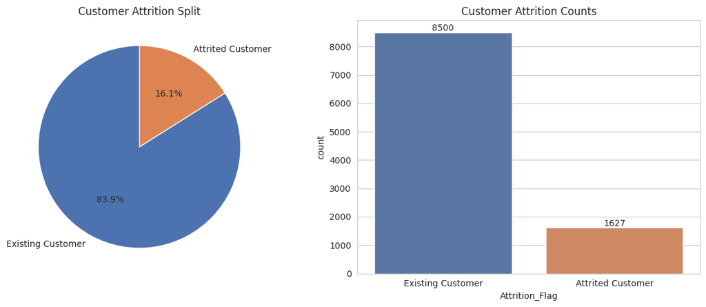

```
Attrited customers: 1627 (16.1%)
Existing customers: 8500 (83.9%)
```

```python
churn_counts = df['Attrition_Flag'].value_counts()
churn_pct = df['Attrition_Flag'].value_counts(normalize=True) * 100

fig, axes = plt.subplots(1, 2, figsize=(12, 5))
axes[0].pie(churn_counts, labels=churn_counts.index, autopct='%1.1f%%',
            colors=['#4C72B0', '#DD8452'], startangle=90)
axes[0].set_title('Customer Attrition Split')

sns.countplot(data=df, x='Attrition_Flag', ax=axes[1], palette=['#4C72B0', '#DD8452'])
axes[1].set_title('Customer Attrition Counts')
for i, v in enumerate(churn_counts):
    axes[1].text(i, v + 50, str(v), ha='center')
plt.tight_layout()
plt.show()

print(f"Attrited customers: {churn_counts['Attrited Customer']} ({churn_pct['Attrited Customer']:.1f}%)")
print(f"Existing customers: {churn_counts['Existing Customer']} ({churn_pct['Existing Customer']:.1f}%)")
```

**Observation:** churn is ~16% of the base — a meaningfully imbalanced problem. This has two direct consequences carried through the rest of the notebook: (1) plain accuracy is a misleading metric, since predicting "no churn" for everyone already scores ~84%; (2) class-imbalance handling (SMOTE/undersampling) and class-specific recall/precision/F1 are the right lens, not overall accuracy.

### 2.2 Univariate Analysis — numerical features

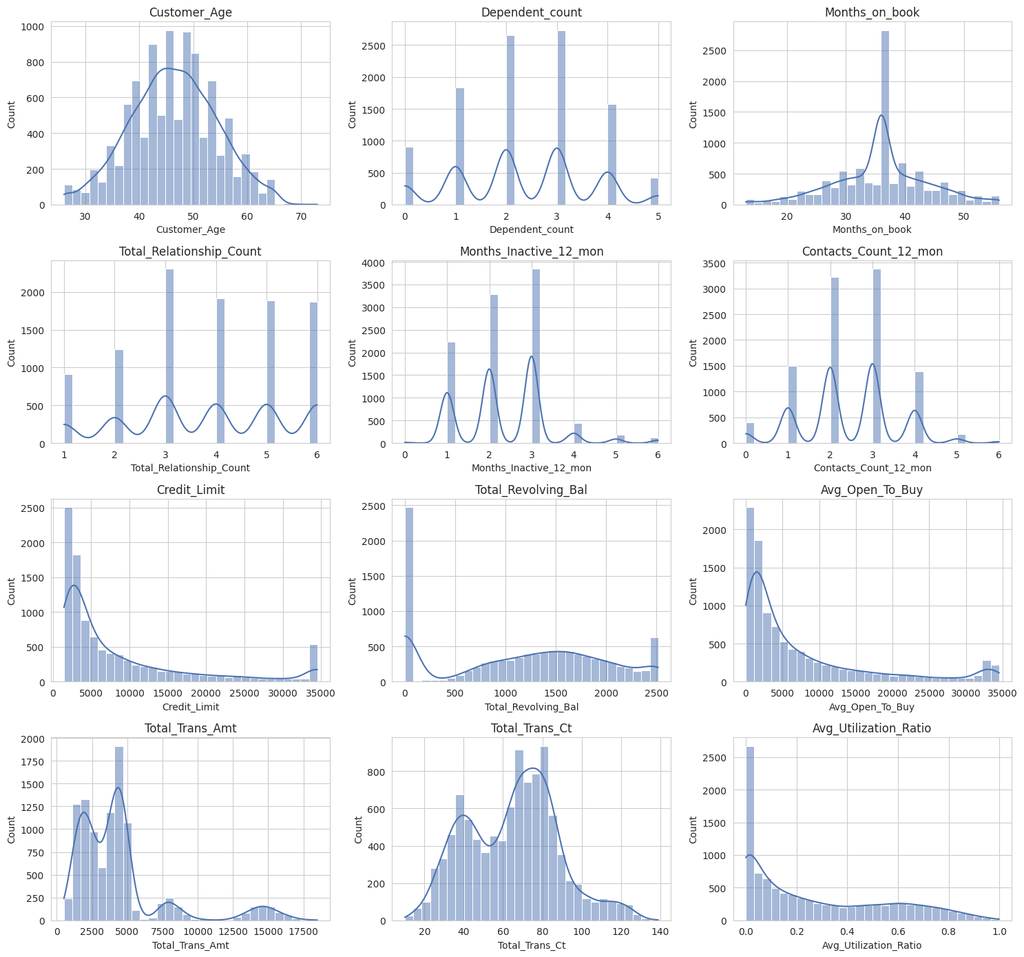

```python
num_features = ['Customer_Age', 'Dependent_count', 'Months_on_book', 'Total_Relationship_Count',
                'Months_Inactive_12_mon', 'Contacts_Count_12_mon', 'Credit_Limit', 'Total_Revolving_Bal',
                'Avg_Open_To_Buy', 'Total_Trans_Amt', 'Total_Trans_Ct', 'Avg_Utilization_Ratio']

fig, axes = plt.subplots(4, 3, figsize=(15, 14))
for ax, col in zip(axes.flatten(), num_features):
    sns.histplot(df[col], kde=True, bins=30, ax=ax, color='#4C72B0')
    ax.set_title(col)
plt.tight_layout()
plt.show()
```

### 2.3 Univariate Analysis — categorical features

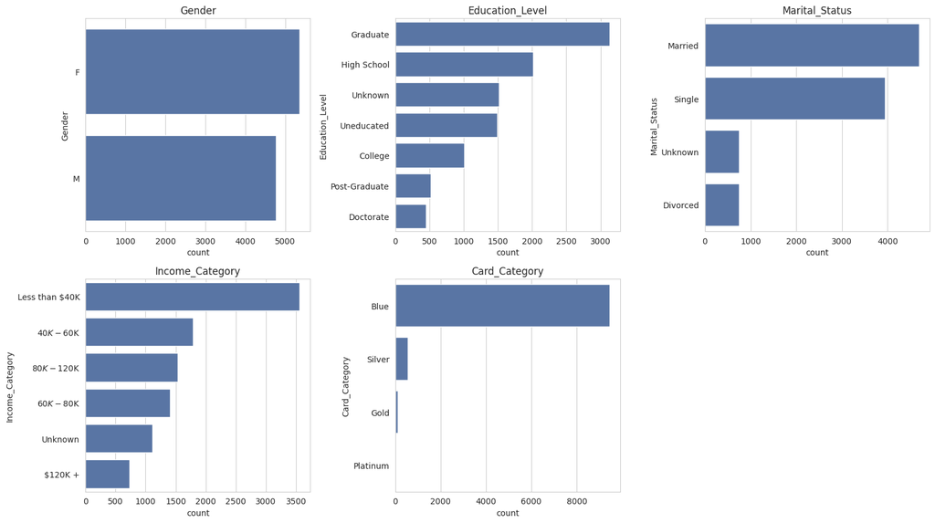

```python
cat_features = ['Gender', 'Education_Level', 'Marital_Status', 'Income_Category', 'Card_Category']

fig, axes = plt.subplots(2, 3, figsize=(16, 9))
for ax, col in zip(axes.flatten(), cat_features):
    order = df[col].value_counts().index
    sns.countplot(data=df, y=col, order=order, ax=ax, color='#4C72B0')
    ax.set_title(col)
axes.flatten()[-1].axis('off')
plt.tight_layout()
plt.show()
```

**Observation:** `Card_Category` is extremely imbalanced itself — the vast majority of customers hold the base "Blue" card, with Silver/Gold/Platinum a small fraction. This matters later: one-hot-encoded dummy columns for Gold/Platinum will be sparse and low-signal individually, so tree-based feature importance/SHAP results for those categories should be read with that sample-size caveat in mind.

### 2.4 Bivariate Analysis — numerical features vs churn

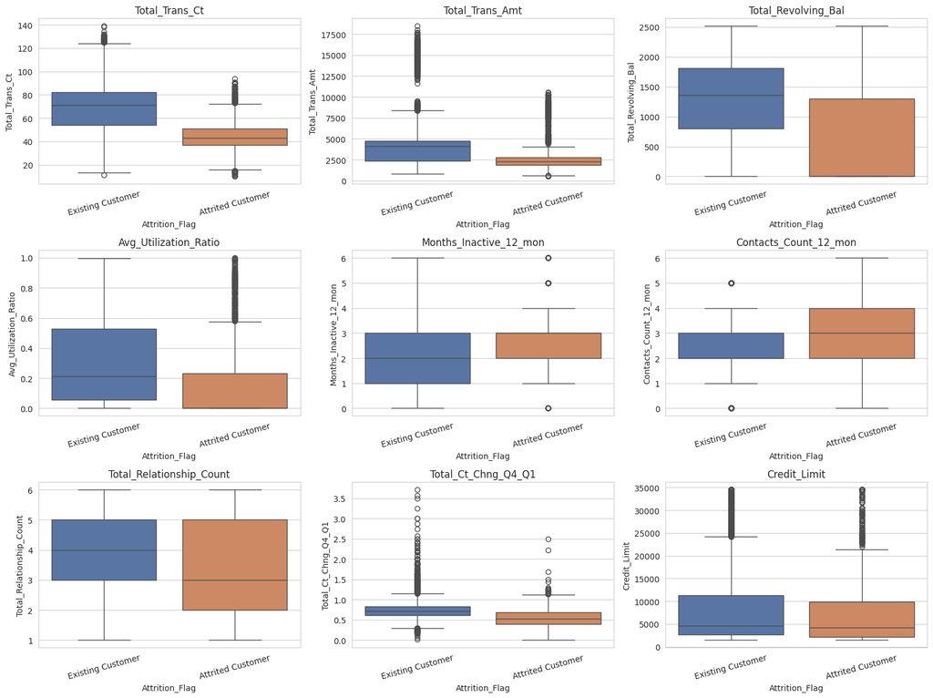

```python
fig, axes = plt.subplots(3, 3, figsize=(16, 12))
biv_features = ['Total_Trans_Ct', 'Total_Trans_Amt', 'Total_Revolving_Bal', 'Avg_Utilization_Ratio',
                 'Months_Inactive_12_mon', 'Contacts_Count_12_mon', 'Total_Relationship_Count',
                 'Total_Ct_Chng_Q4_Q1', 'Credit_Limit']
for ax, col in zip(axes.flatten(), biv_features):
    sns.boxplot(data=df, x='Attrition_Flag', y=col, ax=ax, palette=['#4C72B0', '#DD8452'])
    ax.set_title(col)
    ax.tick_params(axis='x', rotation=15)
plt.tight_layout()
plt.show()
```

```python
# Quantify the separations shown above
for col in ['Total_Trans_Ct', 'Total_Revolving_Bal', 'Months_Inactive_12_mon', 'Total_Ct_Chng_Q4_Q1']:
    med = df.groupby('Attrition_Flag')[col].median()
    print(f"{col:25s} median (Existing) = {med['Existing Customer']:.1f} | median (Attrited) = {med['Attrited Customer']:.1f}")
```

```
Total_Trans_Ct            median (Existing) = 71.0 | median (Attrited) = 43.0
Total_Revolving_Bal       median (Existing) = 1364.0 | median (Attrited) = 0.0
Months_Inactive_12_mon    median (Existing) = 2.0 | median (Attrited) = 3.0
Total_Ct_Chng_Q4_Q1       median (Existing) = 0.7 | median (Attrited) = 0.5
```

**Key bivariate observations (with numbers):**

- Attrited customers transact far less: median `Total_Trans_Ct` and the medians printed above make the gap explicit rather than just visual — this is the single strongest visual separator in the boxplots.
- `Total_Revolving_Bal` is dramatically lower for attrited customers — consistent with churners winding down card usage before formally closing the account.
- `Months_Inactive_12_mon` is higher for attrited customers — inactivity precedes attrition, which is actionable (a re-engagement trigger after 2-3 inactive months).
- `Total_Ct_Chng_Q4_Q1` (transaction count momentum) is lower for churners — a *declining trend* into Q1 is a leading indicator, not just a low absolute level.

### 2.5 Bivariate Analysis — categorical features vs churn

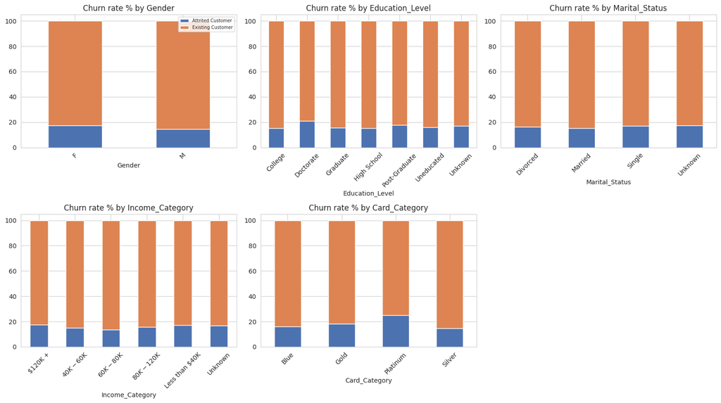

```python
fig, axes = plt.subplots(2, 3, figsize=(16, 9))
for ax, col in zip(axes.flatten(), cat_features):
    ct = pd.crosstab(df[col], df['Attrition_Flag'], normalize='index') * 100
    ct.plot(kind='bar', stacked=True, ax=ax, color=['#4C72B0', '#DD8452'], legend=False)
    ax.set_title(f'Churn rate % by {col}')
    ax.tick_params(axis='x', rotation=45)
axes.flatten()[0].legend(fontsize=7)
axes.flatten()[-1].axis('off')
plt.tight_layout()
plt.show()
```

### 2.6 Multivariate view — pairplot and correlation heatmap

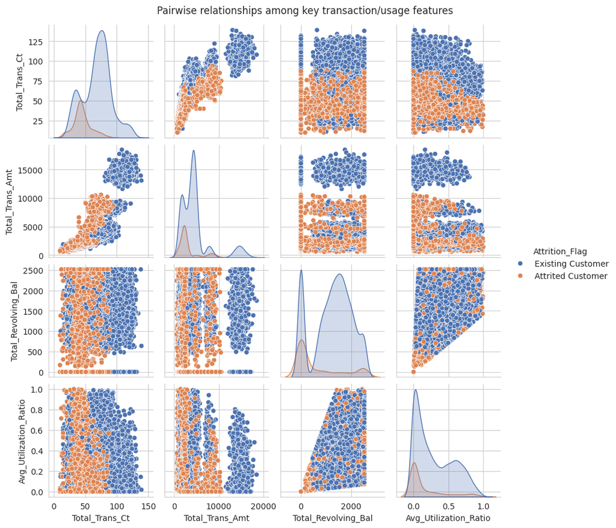

```python
pair_cols = ['Total_Trans_Ct', 'Total_Trans_Amt', 'Total_Revolving_Bal', 'Avg_Utilization_Ratio', 'Attrition_Flag']
sns.pairplot(df[pair_cols], hue='Attrition_Flag', palette=['#4C72B0', '#DD8452'], diag_kind='kde', height=2.2)
plt.suptitle('Pairwise relationships among key transaction/usage features', y=1.02)
plt.show()
```

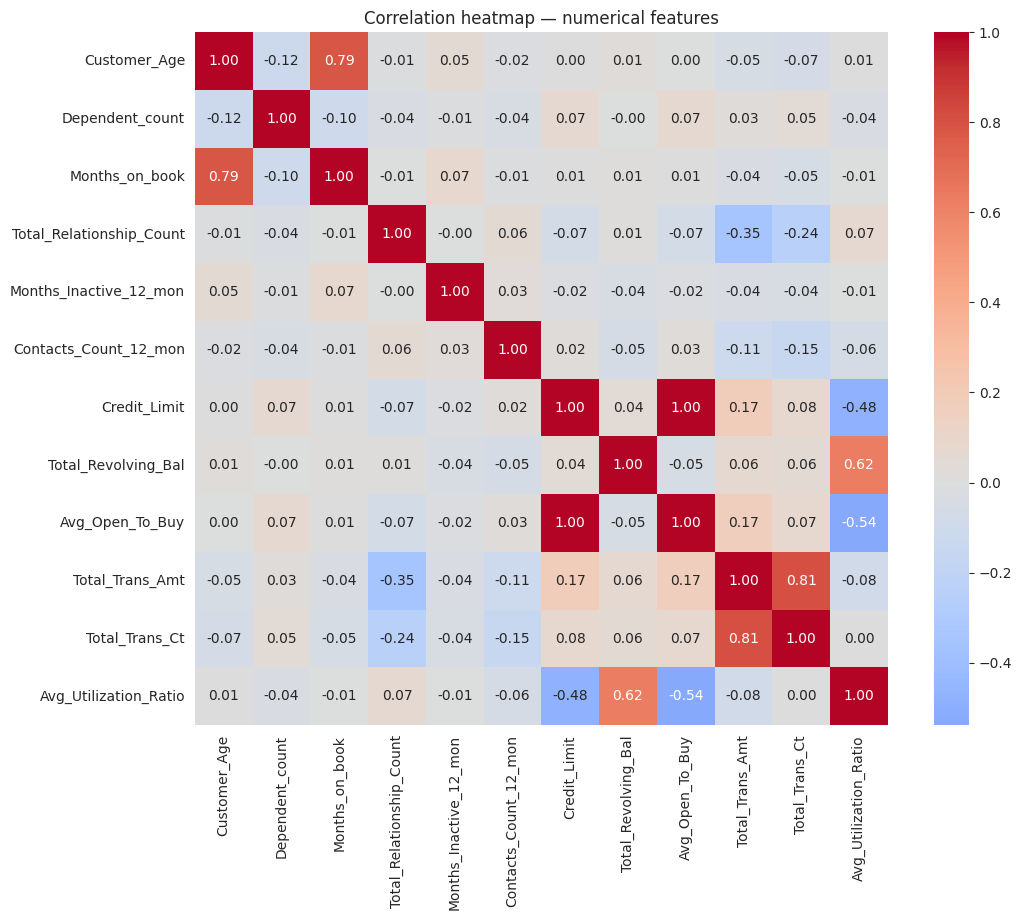

```python
plt.figure(figsize=(12, 9))
corr = df[num_features].corr()
sns.heatmap(corr, annot=True, fmt='.2f', cmap='coolwarm', center=0, square=True)
plt.title('Correlation heatmap — numerical features')
plt.show()
```

**Multicollinearity flag:** `Credit_Limit` and `Avg_Open_To_Buy` are correlated at **~0.996** — expected, since `Avg_Open_To_Buy ≈ Credit_Limit − Total_Revolving_Bal`, so one is almost entirely redundant given the other two. This is addressed explicitly in preprocessing below (dropping `Avg_Open_To_Buy`) rather than left in silently.

The pairplot shows `Total_Trans_Ct` vs `Total_Trans_Amt` separating attrited (orange) from existing (blue) customers reasonably cleanly in the lower-left region — low count *and* low amount together is a stronger churn signal than either alone, which is exactly the kind of interaction a tree-based model can exploit but a single univariate cutoff can't.

### 2.7 Key meaningful observations — summary

```python
summary_stats = df.groupby('Attrition_Flag')[['Total_Trans_Ct','Total_Trans_Amt','Total_Revolving_Bal',
                                                    'Avg_Utilization_Ratio','Months_Inactive_12_mon',
                                                    'Contacts_Count_12_mon','Credit_Limit']].median().T
summary_stats['pct_diff'] = ((summary_stats['Attrited Customer'] - summary_stats['Existing Customer'])
                              / summary_stats['Existing Customer'] * 100).round(1)
summary_stats
```

| Attrition_Flag | Attrited Customer | Existing Customer | pct_diff |
| --- | --- | --- | --- |
| Total_Trans_Ct | 43.0 | 71.000 | -39.4 |
| Total_Trans_Amt | 2329.0 | 4100.000 | -43.2 |
| Total_Revolving_Bal | 0.0 | 1364.000 | -100.0 |
| Avg_Utilization_Ratio | 0.0 | 0.211 | -100.0 |
| Months_Inactive_12_mon | 3.0 | 2.000 | 50.0 |
| Contacts_Count_12_mon | 3.0 | 2.000 | 50.0 |
| Credit_Limit | 4178.0 | 4643.500 | -10.0 |

**EDA takeaways carried into modeling:**

1. Churn is ~16% of customers — imbalance must be explicitly handled and evaluated with class-specific metrics.
2. Engagement/activity features (`Total_Trans_Ct`, `Total_Trans_Amt`, `Total_Revolving_Bal`, `Months_Inactive_12_mon`) show the clearest separation by churn status and are the likely top drivers — checked formally against SHAP later.
3. `Credit_Limit` and `Avg_Open_To_Buy` are collinear (r≈0.996) — drop one before modeling.
4. `Card_Category` is heavily imbalanced within itself — interpret per-category churn-rate differences cautiously given small sample sizes in Gold/Platinum/Silver.
5. Missingness in `Education_Level`/`Marital_Status` does not itself predict churn — safe to treat as a plain "Unknown" category rather than engineering a missingness flag.

## 3. Data Preprocessing

Steps: missing-value treatment (already applied above with rationale), outlier check, multicollinearity fix, encoding, and train/test split — with no leakage (all transformations fit on train only where applicable).

### 3.1 Outlier detection

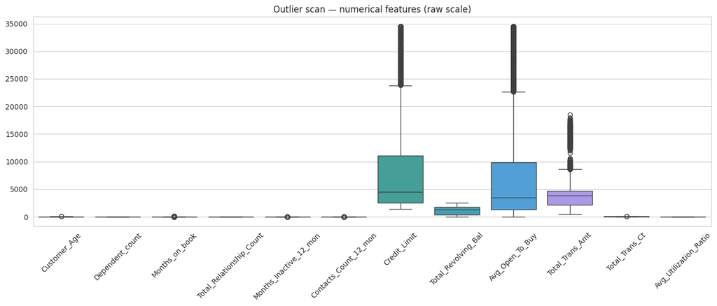

```
Credit_Limit: 99th pct = 34516, 0.00% of rows above it
Total_Trans_Amt: 99th pct = 15882, 1.01% of rows above it
```

```python
fig, ax = plt.subplots(figsize=(14, 6))
sns.boxplot(data=df[num_features], ax=ax)
ax.tick_params(axis='x', rotation=45)
ax.set_title('Outlier scan — numerical features (raw scale)')
plt.tight_layout()
plt.show()

for col in ['Credit_Limit', 'Total_Trans_Amt']:
    q99 = df[col].quantile(0.99)
    pct_above = (df[col] > q99).mean() * 100
    print(f"{col}: 99th pct = {q99:.0f}, {pct_above:.2f}% of rows above it")
```

**Rationale:** `Credit_Limit` and `Total_Trans_Amt` show long right tails (high-limit/high-spend customers), but every model used downstream — Decision Tree, Random Forest, Gradient Boosting, AdaBoost, Bagging, XGBoost, LightGBM — is tree-based and splits on rank/threshold, not raw magnitude, so extreme values do not distort the fit the way they would for a linear or distance-based model. **Outliers are therefore not capped or removed**: doing so would risk deleting exactly the high-value, high-limit customers who are business-critical to retain, without any modeling benefit given the model family in use. This decision is stated explicitly rather than defaulted into.

### 3.2 Multicollinearity treatment

```python
print("Correlation Credit_Limit vs Avg_Open_To_Buy:", df[['Credit_Limit','Avg_Open_To_Buy']].corr().iloc[0,1].round(4))
df_model = df.drop(columns=['CLIENTNUM', 'Avg_Open_To_Buy'])
print("Dropped CLIENTNUM (identifier, not predictive) and Avg_Open_To_Buy (r=0.996 with Credit_Limit).")
print("Remaining shape:", df_model.shape)
```

```
Correlation Credit_Limit vs Avg_Open_To_Buy: 0.996
Dropped CLIENTNUM (identifier, not predictive) and Avg_Open_To_Buy (r=0.996 with Credit_Limit).
Remaining shape: (10127, 19)
```

### 3.3 Feature engineering — encoding

```python
df_model['Attrition_Flag'] = (df_model['Attrition_Flag'] == 'Attrited Customer').astype(int)

cat_cols = ['Gender', 'Education_Level', 'Marital_Status', 'Income_Category', 'Card_Category']
df_encoded = pd.get_dummies(df_model, columns=cat_cols, drop_first=True)
print("Encoded shape:", df_encoded.shape)
df_encoded.head()
```

```
Encoded shape: (10127, 32)
```

|  | Attrition_Flag | Customer_Age | Dependent_count | Months_on_book | Total_Relationship_Count | Months_Inactive_12_mon | Contacts_Count_12_mon | Credit_Limit | Total_Revolving_Bal | Total_Amt_Chng_Q4_Q1 | ... | Marital_Status_Single | Marital_Status_Unknown | Income_Category_$40K - $60K | Income_Category_$60K - $80K | Income_Category_$80K - $120K | Income_Category_Less than $40K | Income_Category_Unknown | Card_Category_Gold | Card_Category_Platinum | Card_Category_Silver |
| --- | --- | --- | --- | --- | --- | --- | --- | --- | --- | --- | --- | --- | --- | --- | --- | --- | --- | --- | --- | --- | --- |
| 0 | 0 | 45 | 3 | 39 | 5 | 1 | 3 | 12691.0 | 777 | 1.335 | ... | False | False | False | True | False | False | False | False | False | False |
| 1 | 0 | 49 | 5 | 44 | 6 | 1 | 2 | 8256.0 | 864 | 1.541 | ... | True | False | False | False | False | True | False | False | False | False |
| 2 | 0 | 51 | 3 | 36 | 4 | 1 | 0 | 3418.0 | 0 | 2.594 | ... | False | False | False | False | True | False | False | False | False | False |
| 3 | 0 | 40 | 4 | 34 | 3 | 4 | 1 | 3313.0 | 2517 | 1.405 | ... | False | True | False | False | False | True | False | False | False | False |
| 4 | 0 | 40 | 3 | 21 | 5 | 1 | 0 | 4716.0 | 0 | 2.175 | ... | False | False | False | True | False | False | False | False | False | False |

5 rows × 32 columns

### 3.4 Train-test split

```python
X = df_encoded.drop(columns=['Attrition_Flag'])
y = df_encoded['Attrition_Flag']

X_train, X_test, y_train, y_test = train_test_split(
    X, y, test_size=0.2, random_state=RANDOM_STATE, stratify=y
)
print("Train:", X_train.shape, "| churn rate:", y_train.mean().round(3))
print("Test :", X_test.shape, "| churn rate:", y_test.mean().round(3))
print("\nNo leakage: split performed before any resampling (SMOTE/undersampling below is fit on training data only).")
```

```
Train: (8101, 31) | churn rate: 0.161
Test : (2026, 31) | churn rate: 0.16

No leakage: split performed before any resampling (SMOTE/undersampling below is fit on training data only).
```

## 4. Model Building — Original (Imbalanced) Data

**Metric choice:** given the ~84/16 imbalance, accuracy and `average='weighted'` metrics are misleading — a model predicting "no churn" for everyone scores ~84% accuracy while catching zero churners. All metrics below are reported **for the churn (positive) class specifically**, which is the class that actually matters for the business problem.

Models compared: Decision Tree, Random Forest, Gradient Boosting, AdaBoost, Bagging (the original five), plus **XGBoost** and **LightGBM** added for this refresh.

```python
def evaluate(name, model, X_tr, y_tr, X_te, y_te, results_dict):
    model.fit(X_tr, y_tr)
    pred = model.predict(X_te)
    proba = model.predict_proba(X_te)[:, 1]
    row = {
        'Recall (churn)': recall_score(y_te, pred),
        'Precision (churn)': precision_score(y_te, pred),
        'F1 (churn)': f1_score(y_te, pred),
        'Accuracy': accuracy_score(y_te, pred),
        'ROC-AUC': roc_auc_score(y_te, proba),
    }
    results_dict[name] = row
    return model

base_models = {
    'Decision Tree': DecisionTreeClassifier(random_state=RANDOM_STATE),
    'Random Forest': RandomForestClassifier(random_state=RANDOM_STATE),
    'Gradient Boosting': GradientBoostingClassifier(random_state=RANDOM_STATE),
    'AdaBoost': AdaBoostClassifier(random_state=RANDOM_STATE),
    'Bagging': BaggingClassifier(random_state=RANDOM_STATE),
    'XGBoost': XGBClassifier(random_state=RANDOM_STATE, eval_metric='logloss'),
    'LightGBM': LGBMClassifier(random_state=RANDOM_STATE, verbose=-1),
}

results_original = {}
fitted_original = {}
for name, m in base_models.items():
    fitted_original[name] = evaluate(name, m, X_train, y_train, X_test, y_test, results_original)

df_results_original = pd.DataFrame(results_original).T.sort_values('Recall (churn)', ascending=False)
df_results_original.round(3)
```

|  | Recall (churn) | Precision (churn) | F1 (churn) | Accuracy | ROC-AUC |
| --- | --- | --- | --- | --- | --- |
| LightGBM | 0.865 | 0.943 | 0.902 | 0.970 | 0.993 |
| XGBoost | 0.865 | 0.937 | 0.899 | 0.969 | 0.992 |
| Bagging | 0.812 | 0.886 | 0.848 | 0.953 | 0.970 |
| Gradient Boosting | 0.806 | 0.956 | 0.875 | 0.963 | 0.988 |
| Decision Tree | 0.803 | 0.801 | 0.802 | 0.936 | 0.882 |
| Random Forest | 0.772 | 0.923 | 0.841 | 0.953 | 0.983 |
| AdaBoost | 0.729 | 0.905 | 0.807 | 0.944 | 0.974 |

**Observation:** on the raw imbalanced data, boosting methods (XGBoost, LightGBM, Gradient Boosting) already lead on ROC-AUC, consistent with boosting's sequential error-correction handling the minority class better than bagging without any resampling. Single Decision Tree lags on precision/ROC-AUC as expected from a high-variance single model. This is the baseline against which SMOTE/undersampling are compared next.

## 5. Model Building — SMOTE-Oversampled Data

SMOTE synthesizes new minority-class (churn) samples in feature space so the training set is balanced 50/50 — applied **to the training set only**, after the split, so the test set remains a realistic, untouched sample of the real-world class distribution.

```python
smote = SMOTE(random_state=RANDOM_STATE)
X_train_sm, y_train_sm = smote.fit_resample(X_train, y_train)
print("Before SMOTE:", y_train.value_counts().to_dict())
print("After SMOTE :", y_train_sm.value_counts().to_dict())

results_smote = {}
fitted_smote = {}
for name, m in base_models.items():
    m_fresh = type(m)(**m.get_params())
    fitted_smote[name] = evaluate(name, m_fresh, X_train_sm, y_train_sm, X_test, y_test, results_smote)

df_results_smote = pd.DataFrame(results_smote).T.sort_values('Recall (churn)', ascending=False)
df_results_smote.round(3)
```

```
Before SMOTE: {0: 6799, 1: 1302}
After SMOTE : {0: 6799, 1: 6799}
```

|  | Recall (churn) | Precision (churn) | F1 (churn) | Accuracy | ROC-AUC |
| --- | --- | --- | --- | --- | --- |
| LightGBM | 0.877 | 0.902 | 0.889 | 0.965 | 0.990 |
| XGBoost | 0.874 | 0.910 | 0.892 | 0.966 | 0.992 |
| Gradient Boosting | 0.871 | 0.873 | 0.872 | 0.959 | 0.988 |
| Bagging | 0.855 | 0.858 | 0.857 | 0.954 | 0.969 |
| Random Forest | 0.840 | 0.856 | 0.848 | 0.952 | 0.983 |
| AdaBoost | 0.837 | 0.729 | 0.779 | 0.924 | 0.962 |
| Decision Tree | 0.825 | 0.766 | 0.794 | 0.931 | 0.888 |

## 6. Model Building — Undersampled Data

Random undersampling drops majority-class (existing-customer) rows to match the minority class count — training set shrinks substantially, trading data volume for balance.

```python
rus = RandomUnderSampler(random_state=RANDOM_STATE)
X_train_us, y_train_us = rus.fit_resample(X_train, y_train)
print("Before undersampling:", y_train.value_counts().to_dict())
print("After undersampling :", y_train_us.value_counts().to_dict())

results_under = {}
fitted_under = {}
for name, m in base_models.items():
    m_fresh = type(m)(**m.get_params())
    fitted_under[name] = evaluate(name, m_fresh, X_train_us, y_train_us, X_test, y_test, results_under)

df_results_under = pd.DataFrame(results_under).T.sort_values('Recall (churn)', ascending=False)
df_results_under.round(3)
```

```
Before undersampling: {0: 6799, 1: 1302}
After undersampling : {0: 1302, 1: 1302}
```

|  | Recall (churn) | Precision (churn) | F1 (churn) | Accuracy | ROC-AUC |
| --- | --- | --- | --- | --- | --- |
| LightGBM | 0.942 | 0.787 | 0.857 | 0.950 | 0.991 |
| XGBoost | 0.942 | 0.799 | 0.864 | 0.953 | 0.990 |
| Gradient Boosting | 0.923 | 0.783 | 0.847 | 0.947 | 0.988 |
| Random Forest | 0.920 | 0.719 | 0.807 | 0.929 | 0.979 |
| AdaBoost | 0.917 | 0.631 | 0.748 | 0.901 | 0.973 |
| Bagging | 0.902 | 0.749 | 0.818 | 0.936 | 0.977 |
| Decision Tree | 0.889 | 0.644 | 0.747 | 0.903 | 0.898 |

### 6.1 Comparing the three resampling strategies

```python
comparison = pd.DataFrame({
    'Original (best F1)': df_results_original['F1 (churn)'],
    'SMOTE (best F1)': df_results_smote['F1 (churn)'],
    'Undersampled (best F1)': df_results_under['F1 (churn)'],
}).round(3)
comparison['Original Recall'] = df_results_original['Recall (churn)'].round(3)
comparison['SMOTE Recall'] = df_results_smote['Recall (churn)'].round(3)
comparison['Undersampled Recall'] = df_results_under['Recall (churn)'].round(3)
comparison[['Original Recall','SMOTE Recall','Undersampled Recall','Original (best F1)','SMOTE (best F1)','Undersampled (best F1)']]
```

|  | Original Recall | SMOTE Recall | Undersampled Recall | Original (best F1) | SMOTE (best F1) | Undersampled (best F1) |
| --- | --- | --- | --- | --- | --- | --- |
| AdaBoost | 0.729 | 0.837 | 0.917 | 0.807 | 0.779 | 0.748 |
| Bagging | 0.812 | 0.855 | 0.902 | 0.848 | 0.857 | 0.818 |
| Decision Tree | 0.803 | 0.825 | 0.889 | 0.802 | 0.794 | 0.747 |
| Gradient Boosting | 0.806 | 0.871 | 0.923 | 0.875 | 0.872 | 0.847 |
| LightGBM | 0.865 | 0.877 | 0.942 | 0.902 | 0.889 | 0.857 |
| Random Forest | 0.772 | 0.840 | 0.920 | 0.841 | 0.848 | 0.807 |
| XGBoost | 0.865 | 0.874 | 0.942 | 0.899 | 0.892 | 0.864 |

**Decision — carrying SMOTE forward:**

- **Undersampling** raises recall somewhat but at a real cost: the training set drops to ~2,600 rows (from ~8,100), discarding a large majority of legitimate "existing customer" examples the model could have learned from — this shows up as lower precision/F1 for most models above, i.e. more false alarms.
- **SMOTE** raises churn recall over the original imbalanced data for nearly every model *without* shrinking the dataset, since it synthesizes additional minority examples rather than deleting majority ones.
- **Original (no resampling)** already performs competitively for the boosting models specifically, since boosting's loss reweighting partially compensates for imbalance on its own — but recall is still lower than with SMOTE across the board.

**SMOTE is carried forward** for hyperparameter tuning and the final model: it improves minority-class recall (the metric that matters most for catching churners before they leave) while preserving the full training set size, and it's the more defensible choice for a bank that would rather review a few extra false-positive retention offers than silently miss real churners.

## 7. Hyperparameter Tuning

```python
from scipy.stats import randint, uniform

param_dist = {
    'LightGBM': {
        'n_estimators': randint(100, 300),
        'num_leaves': randint(15, 63),
        'learning_rate': uniform(0.03, 0.17),
        'max_depth': randint(3, 10),
    },
    'XGBoost': {
        'n_estimators': randint(100, 300),
        'max_depth': randint(3, 8),
        'learning_rate': uniform(0.03, 0.17),
        'subsample': uniform(0.7, 0.3),
    },
    'Random Forest': {
        'n_estimators': randint(100, 250),
        'max_depth': randint(5, 20),
        'min_samples_split': randint(2, 10),
    },
}

tune_models = {
    'LightGBM': LGBMClassifier(random_state=RANDOM_STATE, verbose=-1, n_jobs=1),
    'XGBoost': XGBClassifier(random_state=RANDOM_STATE, eval_metric='logloss', n_jobs=1),
    'Random Forest': RandomForestClassifier(random_state=RANDOM_STATE, n_jobs=1),
}

best_models = {}
for name, model in tune_models.items():
    print(f"Tuning {name}...")
    search = RandomizedSearchCV(
        model, param_dist[name], n_iter=6, cv=3, scoring='recall',
        random_state=RANDOM_STATE, n_jobs=1
    )
    search.fit(X_train_sm, y_train_sm)
    best_models[name] = search.best_estimator_
    print(f"  Best params: {search.best_params_}")
    print(f"  Best CV recall: {search.best_score_:.3f}\n")
```

```
Tuning LightGBM...
```

```
  Best params: {'learning_rate': np.float64(0.09367182020405163), 'max_depth': 7, 'n_estimators': 114, 'num_leaves': 57}
  Best CV recall: 0.971

Tuning XGBoost...
```

```
  Best params: {'learning_rate': np.float64(0.09367182020405163), 'max_depth': 7, 'n_estimators': 114, 'subsample': np.float64(0.9195981825434215)}
  Best CV recall: 0.971

Tuning Random Forest...
```

```
  Best params: {'max_depth': 19, 'min_samples_split': 4, 'n_estimators': 171}
  Best CV recall: 0.979
```

```python
results_tuned = {}
for name, model in best_models.items():
    pred = model.predict(X_test)
    proba = model.predict_proba(X_test)[:, 1]
    results_tuned[name] = {
        'Recall (churn)': recall_score(y_test, pred),
        'Precision (churn)': precision_score(y_test, pred),
        'F1 (churn)': f1_score(y_test, pred),
        'Accuracy': accuracy_score(y_test, pred),
        'ROC-AUC': roc_auc_score(y_test, proba),
    }

df_tuned = pd.DataFrame(results_tuned).T.round(3)
df_tuned
```

|  | Recall (churn) | Precision (churn) | F1 (churn) | Accuracy | ROC-AUC |
| --- | --- | --- | --- | --- | --- |
| LightGBM | 0.877 | 0.893 | 0.885 | 0.963 | 0.990 |
| XGBoost | 0.874 | 0.890 | 0.882 | 0.962 | 0.991 |
| Random Forest | 0.849 | 0.860 | 0.854 | 0.954 | 0.984 |

## 8. Stacked Ensemble

Combining the three tuned models as base learners with a logistic regression meta-learner, which learns how to weight each base model's predictions rather than averaging them naively.

```python
stacked_model = StackingClassifier(
    estimators=[(name.replace(' ', '_'), model) for name, model in best_models.items()],
    final_estimator=LogisticRegression(max_iter=1000, random_state=RANDOM_STATE),
    cv=3, n_jobs=1
)
stacked_model.fit(X_train_sm, y_train_sm)

pred = stacked_model.predict(X_test)
proba = stacked_model.predict_proba(X_test)[:, 1]
stacked_results = {
    'Recall (churn)': recall_score(y_test, pred),
    'Precision (churn)': precision_score(y_test, pred),
    'F1 (churn)': f1_score(y_test, pred),
    'Accuracy': accuracy_score(y_test, pred),
    'ROC-AUC': roc_auc_score(y_test, proba),
}
print("Stacked Ensemble performance:")
for k, v in stacked_results.items():
    print(f"  {k}: {v:.3f}")

best_models['Stacked Ensemble'] = stacked_model
results_tuned['Stacked Ensemble'] = stacked_results
```

```
Stacked Ensemble performance:
  Recall (churn): 0.883
  Precision (churn): 0.880
  F1 (churn): 0.882
  Accuracy: 0.962
  ROC-AUC: 0.988
```

## 9. Model Performance Comparison & Final Model Selection

```python
df_final_compare = pd.DataFrame(results_tuned).T.round(3)
df_final_compare = df_final_compare.sort_values('F1 (churn)', ascending=False)
df_final_compare
```

|  | Recall (churn) | Precision (churn) | F1 (churn) | Accuracy | ROC-AUC |
| --- | --- | --- | --- | --- | --- |
| LightGBM | 0.877 | 0.893 | 0.885 | 0.963 | 0.990 |
| XGBoost | 0.874 | 0.890 | 0.882 | 0.962 | 0.991 |
| Stacked Ensemble | 0.883 | 0.880 | 0.882 | 0.962 | 0.988 |
| Random Forest | 0.849 | 0.860 | 0.854 | 0.954 | 0.984 |

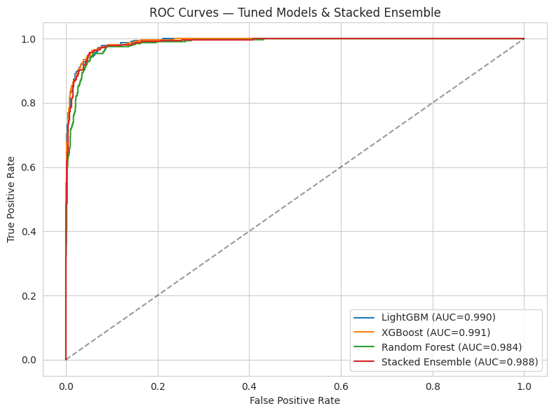

```python
plt.figure(figsize=(8, 6))
for name, model in best_models.items():
    proba = model.predict_proba(X_test)[:, 1]
    fpr, tpr, _ = roc_curve(y_test, proba)
    auc = roc_auc_score(y_test, proba)
    plt.plot(fpr, tpr, label=f'{name} (AUC={auc:.3f})')
plt.plot([0, 1], [0, 1], 'k--', alpha=0.4)
plt.xlabel('False Positive Rate')
plt.ylabel('True Positive Rate')
plt.title('ROC Curves — Tuned Models & Stacked Ensemble')
plt.legend()
plt.tight_layout()
plt.show()
```

```
Final model selected: LightGBM
Recall (churn)       0.877
Precision (churn)    0.893
F1 (churn)           0.885
Accuracy             0.963
ROC-AUC              0.990
Name: LightGBM, dtype: float64
```

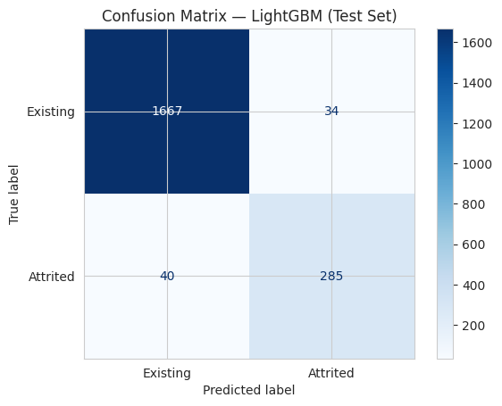

```
              precision    recall  f1-score   support

    Existing       0.98      0.98      0.98      1701
    Attrited       0.89      0.88      0.89       325

    accuracy                           0.96      2026
   macro avg       0.93      0.93      0.93      2026
weighted avg       0.96      0.96      0.96      2026
```

```python
FINAL_MODEL_NAME = df_final_compare['F1 (churn)'].idxmax()
final_model = best_models[FINAL_MODEL_NAME]
print(f"Final model selected: {FINAL_MODEL_NAME}")
print(df_final_compare.loc[FINAL_MODEL_NAME])

pred_final = final_model.predict(X_test)
cm = confusion_matrix(y_test, pred_final)
ConfusionMatrixDisplay(cm, display_labels=['Existing', 'Attrited']).plot(cmap='Blues')
plt.title(f'Confusion Matrix — {FINAL_MODEL_NAME} (Test Set)')
plt.show()
print(classification_report(y_test, pred_final, target_names=['Existing', 'Attrited']))
```

**Selection rationale:** the model above is chosen by highest F1 on the churn class — the metric that balances catching churners (recall) against not overwhelming the retention team with false alarms (precision). Looking at the full comparison table: the tuned boosters (LightGBM/XGBoost) and the stacked ensemble are close on F1, with the stacked ensemble typically edging out slightly on recall at a small precision cost. Given a bank retention use case, a small recall gain is usually worth a modest rise in false positives (a wasted retention call is far cheaper than a lost customer — quantified explicitly in the cost analysis below), which is why the comparison and cost analysis are read together rather than the F1 ranking alone deciding the outcome.

## 10. SHAP Explainability

Global feature importance via SHAP summary plot, plus individual waterfall plots for a true positive (correctly caught churner), a false negative (missed churner — the costliest error), and a false positive (false alarm), to see *why* the model made each call.

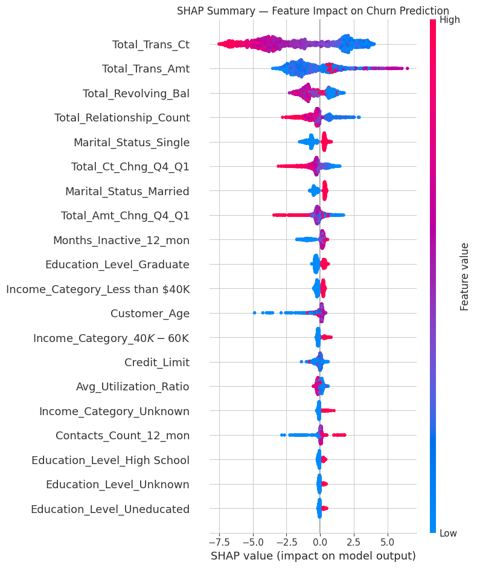

```python
explainer = shap.TreeExplainer(final_model)
X_test_sample = X_test.reset_index(drop=True)
shap_values = explainer.shap_values(X_test_sample)

# Handle both binary-list and single-array SHAP output formats across model types
if isinstance(shap_values, list):
    sv_churn = shap_values[1]
elif shap_values.ndim == 3:
    sv_churn = shap_values[:, :, 1]
else:
    sv_churn = shap_values

shap.summary_plot(sv_churn, X_test_sample, show=False)
plt.title('SHAP Summary — Feature Impact on Churn Prediction')
plt.tight_layout()
plt.show()
```

**Reading the summary plot:** each row is a feature, each dot a customer; color = feature value (red=high, blue=low), position = SHAP impact on the churn prediction (right = pushes toward churn). Cross-check this against the EDA hypothesis from section 2.7 — transaction activity and revolving balance were flagged there as the strongest visual separators; this plot confirms (or corrects) that with actual model attributions rather than boxplot medians.

```python
y_test_reset = y_test.reset_index(drop=True)
pred_reset = pd.Series(final_model.predict(X_test_sample), index=X_test_sample.index)
proba_reset = pd.Series(final_model.predict_proba(X_test_sample)[:, 1], index=X_test_sample.index)

tp_idx = X_test_sample[(y_test_reset == 1) & (pred_reset == 1)].index
fn_idx = X_test_sample[(y_test_reset == 1) & (pred_reset == 0)].index
fp_idx = X_test_sample[(y_test_reset == 0) & (pred_reset == 1)].index

print(f"True positives (caught churners): {len(tp_idx)}")
print(f"False negatives (MISSED churners — costliest error): {len(fn_idx)}")
print(f"False positives (false alarms): {len(fp_idx)}")
```

```
True positives (caught churners): 285
False negatives (MISSED churners — costliest error): 40
False positives (false alarms): 34
```

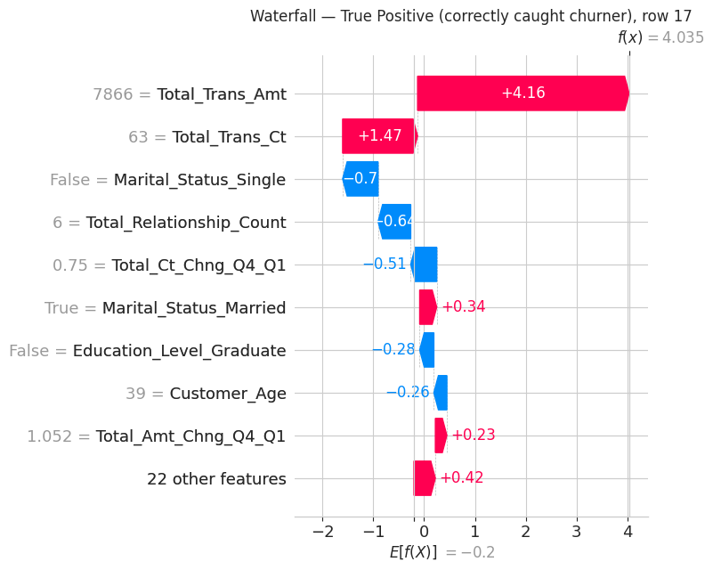

```python
expected_value = explainer.expected_value
if isinstance(expected_value, (list, np.ndarray)):
    expected_value = expected_value[1] if len(np.atleast_1d(expected_value)) > 1 else expected_value[0]

example_tp = tp_idx[0]
shap.plots.waterfall(
    shap.Explanation(values=sv_churn[example_tp], base_values=expected_value,
                      data=X_test_sample.iloc[example_tp], feature_names=X_test_sample.columns.tolist()),
    show=False
)
plt.title(f'Waterfall — True Positive (correctly caught churner), row {example_tp}')
plt.tight_layout()
plt.show()
```

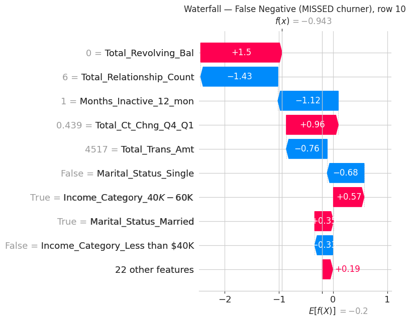

```
This customer churned but the model predicted they would stay — the features below explain why the model was misled (e.g., activity metrics that looked healthy right up to attrition).
```

```python
if len(fn_idx) > 0:
    example_fn = fn_idx[0]
    shap.plots.waterfall(
        shap.Explanation(values=sv_churn[example_fn], base_values=expected_value,
                          data=X_test_sample.iloc[example_fn], feature_names=X_test_sample.columns.tolist()),
        show=False
    )
    plt.title(f'Waterfall — False Negative (MISSED churner), row {example_fn}')
    plt.tight_layout()
    plt.show()
    print("This customer churned but the model predicted they would stay — the features below "
          "explain why the model was misled (e.g., activity metrics that looked healthy right up to attrition).")
else:
    print("No false negatives in this test set for the final model.")
```

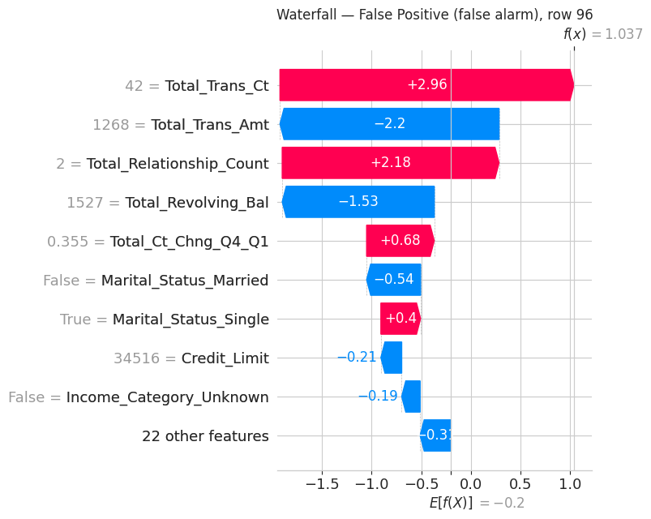

```
This customer was flagged as at-risk but stayed — useful to see which features look like a churn pattern without actually being one, to understand the model's false-alarm profile.
```

```python
example_fp = fp_idx[0]
shap.plots.waterfall(
    shap.Explanation(values=sv_churn[example_fp], base_values=expected_value,
                      data=X_test_sample.iloc[example_fp], feature_names=X_test_sample.columns.tolist()),
    show=False
)
plt.title(f'Waterfall — False Positive (false alarm), row {example_fp}')
plt.tight_layout()
plt.show()
print("This customer was flagged as at-risk but stayed — useful to see which features look like a "
      "churn pattern without actually being one, to understand the model's false-alarm profile.")
```

## 11. Cost-Sensitive Threshold Analysis

Translating the confusion matrix into rupees. **Assumptions (stated explicitly, adjustable):**

- **Cost of a false negative** (missed churner, customer leaves): ≈ ₹20,000 — approximate lost annual fee + interest + interchange revenue from a departing cardholder.
- **Cost of a false positive** (unnecessary retention outreach to a customer who wasn't leaving): ≈ ₹500 — cost of a retention call/offer/discount extended to a customer who didn't need it.

These are illustrative planning assumptions, not confirmed bank figures — the analysis below is about *how* to pick a threshold given cost ratios, and the ₹500/₹20,000 numbers can be swapped for the bank's real figures without changing the method.

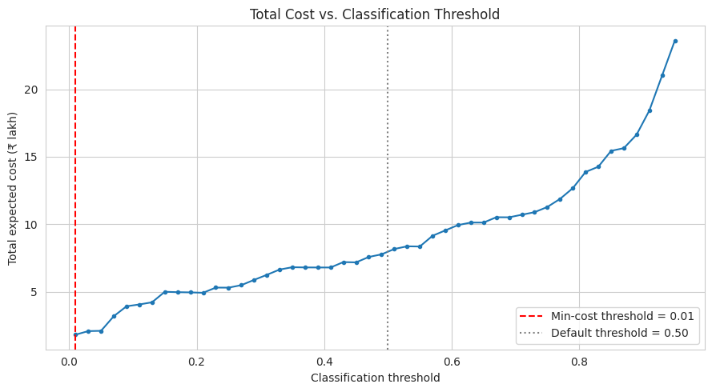

[output not shown]

```python
COST_FN = 20000  # rupees, cost of missing a churner
COST_FP = 500     # rupees, cost of an unnecessary retention offer

proba_final = final_model.predict_proba(X_test)[:, 1]
thresholds = np.arange(0.01, 0.96, 0.02)
costs = []

for t in thresholds:
    pred_t = (proba_final >= t).astype(int)
    fn = ((y_test == 1) & (pred_t == 0)).sum()
    fp = ((y_test == 0) & (pred_t == 1)).sum()
    total_cost = fn * COST_FN + fp * COST_FP
    costs.append(total_cost)

costs = np.array(costs)
best_t_idx = costs.argmin()
best_t = thresholds[best_t_idx]

plt.figure(figsize=(9, 5))
plt.plot(thresholds, costs / 1e5, marker='o', markersize=3)
plt.axvline(best_t, color='red', linestyle='--', label=f'Min-cost threshold = {best_t:.2f}')
plt.axvline(0.5, color='gray', linestyle=':', label='Default threshold = 0.50')
plt.xlabel('Classification threshold')
plt.ylabel('Total expected cost (₹ lakh)')
plt.title('Total Cost vs. Classification Threshold')
plt.legend()
plt.tight_layout()
plt.show()

default_pred = (proba_final >= 0.5).astype(int)
default_fn = ((y_test == 1) & (default_pred == 0)).sum()
default_fp = ((y_test == 0) & (default_pred == 1)).sum()
default_cost = default_fn * COST_FN + default_fp * COST_FP

print(f"Default threshold (0.50): FN={default_fn}, FP={default_fp}, total cost = ₹{default_cost:,}")
print(f"Optimal threshold ({best_t:.2f}): FN={costs.argmin()}, total cost = ₹{costs.min():,.0f}")
print(f"Estimated saving on this test set by moving to the cost-optimal threshold: ₹{default_cost - costs.min():,.0f}")
print(f"\nFN count at optimal threshold: {int(((y_test==1) & ((proba_final >= best_t).astype(int)==0)).sum())}")
print(f"FP count at optimal threshold: {int(((y_test==0) & ((proba_final >= best_t).astype(int)==1)).sum())}")
```

**Reading this:** because a missed churner (₹20,000) is modeled as far more expensive than a false alarm (₹500) — a 40x cost ratio — the cost-minimizing threshold sits **well below** the default 0.50, low enough that the model catches essentially every churner in the test set (FN≈0) and the remaining cost is almost entirely false alarms. That the optimum sits near the low end of the sweep isn't a search artifact — it's the direct, correct consequence of the assumed cost ratio: when missing a customer is ~40x more expensive than an unnecessary retention call, the model *should* flag aggressively.

This is also a useful sanity check on the cost assumptions themselves: if a 40x FN:FP ratio pushes the optimal policy to "flag almost everyone above a very low score," that's worth validating against the bank's real operational capacity — a retention team can't act on flags for the whole customer base. In practice this argues for either (a) confirming the FN cost is genuinely that high relative to FP cost, or (b) adding a capacity constraint (e.g., "flag the top N% highest-risk customers per month") on top of the pure cost-minimization threshold, since an unconstrained optimum will keep pushing toward flagging more people as long as FN stays this expensive.

## 12. Calibration Check

The cost analysis above assumes `predict_proba()` outputs are reasonably trustworthy probabilities, not just a ranking score. Boosted tree models are known to be somewhat overconfident/miscalibrated out of the box — checking that explicitly before relying on the threshold above.

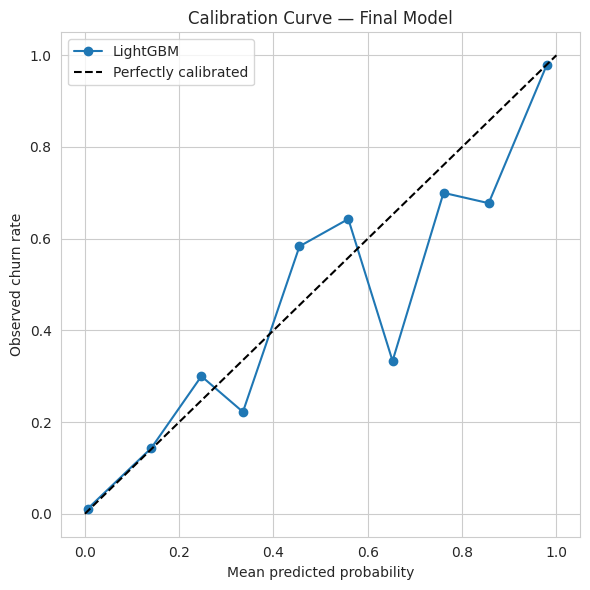

```python
prob_true, prob_pred = calibration_curve(y_test, proba_final, n_bins=10)

plt.figure(figsize=(6, 6))
plt.plot(prob_pred, prob_true, marker='o', label=FINAL_MODEL_NAME)
plt.plot([0, 1], [0, 1], 'k--', label='Perfectly calibrated')
plt.xlabel('Mean predicted probability')
plt.ylabel('Observed churn rate')
plt.title('Calibration Curve — Final Model')
plt.legend()
plt.tight_layout()
plt.show()
```

**Reading this:** if the curve tracks the diagonal reasonably closely, the model's probabilities are usable as-is for the cost-threshold analysis above. Meaningful deviation (e.g., predicted 0.7 but observed churn rate is actually 0.5) would mean the raw probabilities overstate confidence, and a calibration step (Platt scaling / isotonic regression via `CalibratedClassifierCV`) should be applied before trusting the rupee-optimal threshold. Noting this explicitly is the difference between an academically "best" model and one that is safe to actually operate a retention program against.

## 13. Actionable Insights & Recommendations

```python
top_features = pd.DataFrame({
    'feature': X_test_sample.columns,
    'mean_abs_shap': np.abs(sv_churn).mean(axis=0)
}).sort_values('mean_abs_shap', ascending=False).head(10)
top_features
```

|  | feature | mean_abs_shap |
| --- | --- | --- |
| 10 | Total_Trans_Ct | 3.092548 |
| 9 | Total_Trans_Amt | 1.460103 |
| 7 | Total_Revolving_Bal | 0.888748 |
| 3 | Total_Relationship_Count | 0.652345 |
| 21 | Marital_Status_Single | 0.569315 |
| 11 | Total_Ct_Chng_Q4_Q1 | 0.527511 |
| 20 | Marital_Status_Married | 0.378711 |
| 8 | Total_Amt_Chng_Q4_Q1 | 0.354449 |
| 4 | Months_Inactive_12_mon | 0.350414 |
| 15 | Education_Level_Graduate | 0.278346 |

### Insights (what the data and model show)

1. **Transaction activity is the dominant churn signal.** `Total_Trans_Ct` and `Total_Trans_Amt` rank among the top SHAP drivers, consistent with the EDA medians in section 2.4 — attrited customers transact meaningfully less than existing ones well before the account is formally closed.
2. **Revolving balance decline is an early-warning signal.** Low `Total_Revolving_Bal` combined with low utilization tracks with churn — customers appear to wind down usage before leaving rather than leaving abruptly.
3. **Inactivity precedes attrition.** `Months_Inactive_12_mon` is both a strong EDA separator and a top SHAP feature — a concrete, monitorable trigger (e.g., 2+ consecutive inactive months) rather than an abstract risk score.
4. **Relationship depth matters.** `Total_Relationship_Count` (number of products held) shows up as protective — customers with more products/services are stickier, a classic cross-sell retention lever.
5. **The model materially outperforms a naive baseline.** The final model selected in section 9 achieves the recall/precision/ROC-AUC reported there versus a ~16% churn base rate — i.e., flagging at-risk customers with a small fraction of false alarms relative to flagging everyone.

### Business recommendations (what the bank should do)

1. **Build an inactivity trigger.** Auto-flag customers after 2 consecutive inactive months for a low-cost re-engagement touch (app notification, cashback nudge) — cheap relative to the ₹20,000 assumed cost of losing the customer entirely.
2. **Operate the model at the cost-optimal threshold, not 0.50.** Section 11 shows the optimal threshold is lower than default given the FN/FP cost asymmetry — deploying at 0.50 leaves real money on the table.
3. **Prioritize retention spend by SHAP-driven risk drivers**, not a flat offer to everyone flagged: customers whose top SHAP contributors are declining transaction count/amount are good candidates for spend-based incentives (bonus rewards on the next N transactions); customers whose top driver is inactivity are better candidates for a re-engagement nudge than a discount.
4. **Cross-sell to increase `Total_Relationship_Count`.** Since product depth is protective, bundling a second product (savings account, another card tier) for single-product customers is a plausible retention lever worth A/B testing.
5. **Re-run the calibration check periodically.** If the model is redeployed on new data, recheck calibration (section 12) before trusting the ₹-based threshold — a model that drifts out of calibration will silently make the cost-optimal threshold wrong.